# Optimizing WOrkout with Wearable Tech

Kameron Billingsley

12/15/2019

## Overview

Wearable technology has openned up opportunities to quantify and qualify athletic performance of users. In this report, we build a ML model that accurately classifies correct and incorrect attempts at various exercises using accelerometer data onboard our test athletes and some of the equipment they are using

## The Data

The data provided has many mostly-empty columns due to the numerical treatment given by the original researchers. We start by scurbbing these columns

```r
pml_training<-read.csv("C:/Users/Kameron/Documents/R/courseraPlaygrnd/pml-training.csv")
pml_train_clean<-pml_training[,which(pml_training[1,]!="NA" & pml_training[1,]!="")] #first row was mostly empty. keep only columns with data!
```

Next we take out all the unnecessary labels. Timestamps, names, column numbers all go. Only accelerometer data stays

```r
pml_train_clean<-pml_train_clean[,-c(1:7)]
```

Now we look at a correlation matrix to see if data reduction would yield any advantage

```r
library(caret)
```

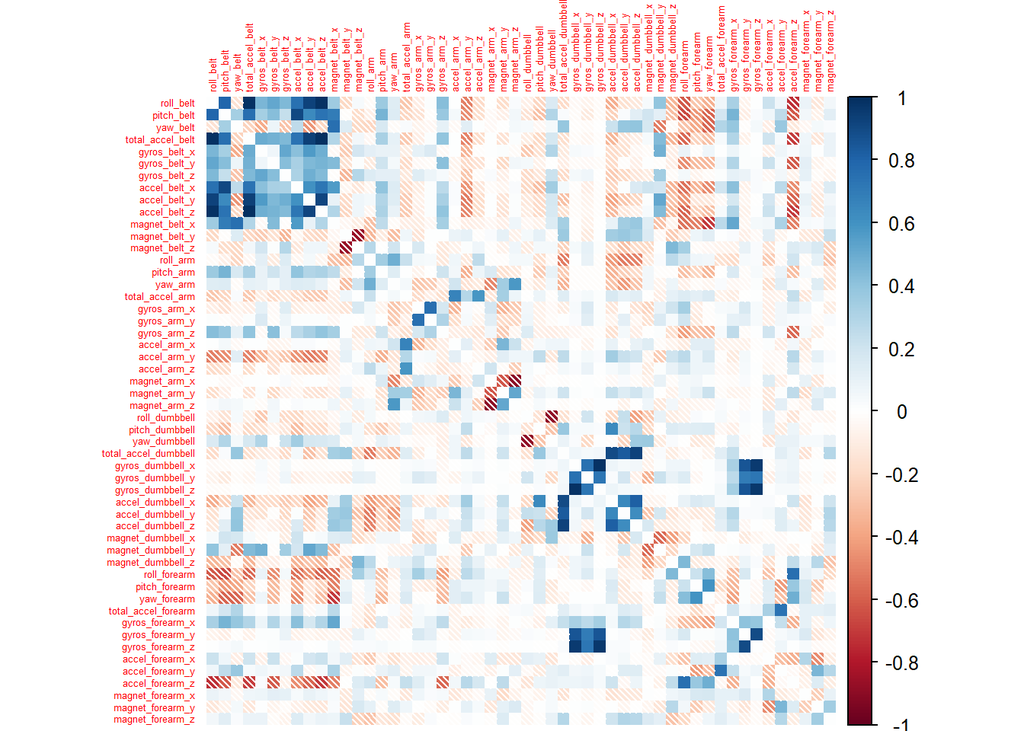

```r
library(corrplot)
cplotM<-cor(abs(pml_train_clean[,-53]))#exclude the result variable
diag(cplotM)<-0
corrplot(cplotM, method="shade", tl.cex=.4)
```

From the matrix there are a few variables that correlate very strongly with each other, making this data set a good candidate for data reduction. For our purposes, we will use principal component analysis (PCA) to capture 95% of the variance in (hopefully) fewer component variables

```r
proc<-preProcess(pml_train_clean[,-53], method="pca")
proc #view the results
```

```
## Created from 19622 samples and 52 variables
##
## Pre-processing:
##   - centered (52)
##   - ignored (0)
##   - principal component signal extraction (52)
##   - scaled (52)
##
## PCA needed 25 components to capture 95 percent of the variance
```

We were able to get 95% of the variance in just 25 components, a significant improvement over the original 52 variables. This will make our model leaner and faster during training and run times

## The Model

There are many good options when considering a classification algorithm. Random forest offers high accuracy at the cost of low speed and poor interpretability. Because speed and interpretability are not really important to us here, those costs are justified

```r
tc<-trainControl(method="cv", number=7) #setup for 7-fold cross valiation
nuMod<-train(y=pml_train_clean$classe, x=predict(proc, pml_train_clean[,-53]), method="rf", trControl=tc)
nuMod #view summary
```

```
## Random Forest
##
## 19622 samples
##    25 predictor
##     5 classes: 'A', 'B', 'C', 'D', 'E'
##
## No pre-processing
## Resampling: Cross-Validated (7 fold)
## Summary of sample sizes: 16820, 16818, 16819, 16819, 16819, 16819, ...
## Resampling results across tuning parameters:
##
##   mtry  Accuracy   Kappa
##    2    0.9815004  0.9765945
##   13    0.9784936  0.9727930
##   25    0.9702380  0.9623551
##
## Accuracy was used to select the optimal model using the largest value.
## The final value used for the model was mtry = 2.
```